# 3.0 Build Machine Learning Model for Healthcare Provider Fraud Dataset

`Author: James Smith`

`Date of Creation: 21/03/2020`

`Programming for Big Data: Assignment 2`

`Overview: The purpose of this notebook is to build a predictive model to detect Healthcare Provider Fraud.`

# Load Dataset

```python
# For working with directories
import os
# Finds pathnames matching a specified pattern
import glob
# For data analysis and manipulation
import pandas as pd
# Linear algebra
import numpy as np
# To time processes
import time
# Quick EDA
from pandas_profiling import ProfileReport
# Working with dates
import datetime
# Plotting
import matplotlib.pyplot as plt
import seaborn as sns

from sklearn.model_selection import train_test_split
```

```python
# Define working directory
path = os.getcwd()

# Define parent/project directory
project_directory = os.path.abspath(os.path.join(path, os.pardir))

# project_directory and data_folder are defined earlier
dataset_name = "2.0_cleaned_dataset"
processed_data_folder_path = os.path.join(project_directory,
                                          "data", "processed",
                                          dataset_name)
# Load
df = pd.read_csv(processed_data_folder_path + ".csv")
```

```python
df = df.drop("Unnamed: 0", axis = 1)
print("The table contains {} rows and {} columns".format(df.shape[0], df.shape[1]))
df.head()
```

```
The table contains 558211 rows and 41 columns
```

|  | BeneID | ClaimID | ClaimStartDt | ClaimEndDt | Provider | InscClaimAmtReimbursed | inpatient_status | DOB | Gender | Race | ... | ClaimStartDt_year | ClaimStartDt_yearmonth | ClaimStartDt_dow | ClaimEndDt_year | ClaimEndDt_yearmonth | ClaimEndDt_dow | ClaimLength | DOB_year | OperatingPhysician_flag | OtherPhysician_flag |
| --- | --- | --- | --- | --- | --- | --- | --- | --- | --- | --- | --- | --- | --- | --- | --- | --- | --- | --- | --- | --- | --- |
| 0 | BENE11001 | CLM46614 | 2009-04-12 | 2009-04-18 | PRV55912 | 26000 | 0 | 1943-01-01 | 1 | 1 | ... | 2009 | 20094 | 6 | 2009 | 20094 | 5 | 6 | 1943 | 0 | 0 |
| 1 | BENE16973 | CLM565430 | 2009-09-06 | 2009-09-06 | PRV55912 | 50 | 1 | 1932-05-01 | 1 | 1 | ... | 2009 | 20099 | 6 | 2009 | 20099 | 6 | 0 | 1932 | 1 | 0 |
| 2 | BENE17521 | CLM34721 | 2009-01-20 | 2009-02-01 | PRV55912 | 19000 | 0 | 1913-12-01 | 2 | 1 | ... | 2009 | 20091 | 1 | 2009 | 20092 | 6 | 12 | 1913 | 1 | 1 |
| 3 | BENE21718 | CLM72336 | 2009-10-17 | 2009-11-04 | PRV55912 | 17000 | 0 | 1922-10-01 | 1 | 1 | ... | 2009 | 200910 | 5 | 2009 | 200911 | 2 | 18 | 1922 | 1 | 0 |
| 4 | BENE22934 | CLM73394 | 2009-10-25 | 2009-10-29 | PRV55912 | 13000 | 0 | 1930-07-01 | 2 | 1 | ... | 2009 | 200910 | 6 | 2009 | 200910 | 3 | 4 | 1930 | 1 | 1 |

5 rows × 41 columns

```python
df.dtypes
```

```
BeneID                             object
ClaimID                            object
ClaimStartDt                       object
ClaimEndDt                         object
Provider                           object
InscClaimAmtReimbursed              int64
inpatient_status                    int64
DOB                                object
Gender                              int64
Race                                int64
RenalDiseaseIndicator              object
State                               int64
County                              int64
NoOfMonths_PartACov                 int64
NoOfMonths_PartBCov                 int64
ChronicCond_Alzheimer               int64
ChronicCond_Heartfailure            int64
ChronicCond_KidneyDisease           int64
ChronicCond_Cancer                  int64
ChronicCond_ObstrPulmonary          int64
ChronicCond_Depression              int64
ChronicCond_Diabetes                int64
ChronicCond_IschemicHeart           int64
ChronicCond_Osteoporasis            int64
ChronicCond_rheumatoidarthritis     int64
ChronicCond_stroke                  int64
IPAnnualReimbursementAmt            int64
IPAnnualDeductibleAmt               int64
OPAnnualReimbursementAmt            int64
PotentialFraud                     object
Dead                                int64
ClaimStartDt_year                   int64
ClaimStartDt_yearmonth              int64
ClaimStartDt_dow                    int64
ClaimEndDt_year                     int64
ClaimEndDt_yearmonth                int64
ClaimEndDt_dow                      int64
ClaimLength                         int64
DOB_year                            int64
OperatingPhysician_flag             int64
OtherPhysician_flag                 int64
dtype: object
```

# Prepare Data for ML Models

Extract the labels from the dataframe

```python
Y = df["PotentialFraud"].apply(lambda x: 1 if x == "Yes" else 0)
X = df.drop("PotentialFraud", axis = 1)
```

Split data into 80% Train and 20% Test. Set random state so that results are reproducable

```python
trainX, testX, trainY, testY = train_test_split(X, Y, test_size = 0.2,
                                         random_state = 42)
```

## Sample Training Data

Sample training data so that we can run models with reasonable speeds.

Once we have a promising model we can have a larger sample so that the model can pick up more complex patterns

```python
sample_fraction = 0.2

trainX = trainX.sample(frac = sample_fraction, random_state = 42)
trainY = trainY[trainY.index.isin(trainX.index)]

print(trainX.shape)
print(trainY.shape)
```

```
(89314, 40)
(89314,)
```

## Diving columns into numerical and categorical

Since we will have apply different preprocessing to both types we will split data into numerical and categorical. Some columns such as `ClaimStartDt` will be removed in the process.

Since we will use one hot encoding later, we also will drop columns with very high cardinality - as raised in the EDA section in the last notebook

- BeneID
- Provider

```python
num_cols = ['InscClaimAmtReimbursed', 'NoOfMonths_PartACov',
            'NoOfMonths_PartBCov', 'NoOfMonths_PartBCov',
            'IPAnnualReimbursementAmt', 'IPAnnualDeductibleAmt',
            'OPAnnualReimbursementAmt', 'ClaimLength']

cat_cols = ['inpatient_status', 'Gender', 'Race',
            'RenalDiseaseIndicator', 'State', 'County', 'ChronicCond_Alzheimer',
            'ChronicCond_Heartfailure', 'ChronicCond_KidneyDisease',
            'ChronicCond_Cancer', 'ChronicCond_ObstrPulmonary',
            'ChronicCond_Depression', 'ChronicCond_Diabetes',
            'ChronicCond_IschemicHeart', 'ChronicCond_Osteoporasis',
            'ChronicCond_rheumatoidarthritis', 'ChronicCond_stroke','Dead',
            'ClaimStartDt_year', 'ClaimStartDt_yearmonth', 'ClaimStartDt_dow',
            'ClaimEndDt_year', 'ClaimEndDt_yearmonth', 'ClaimEndDt_dow',
            'DOB_year', 'OperatingPhysician_flag', 'OtherPhysician_flag']

# Ensure we only keep these columns
```

## Building Preprocessing Pipeline

Standardise numerical attributes so they have same scale. StandardScaler - zero mean with unit variance

Use one hot encoding for categorical attributes.

```python
from sklearn.pipeline import Pipeline
from sklearn.preprocessing import StandardScaler
from sklearn.preprocessing import OneHotEncoder

from sklearn.compose import ColumnTransformer

# include handle_unknown='ignore' to not get error when new categories appear in test
full_pipeline = ColumnTransformer([
                                ("num", StandardScaler(), num_cols),
                                ("cat", OneHotEncoder(handle_unknown='ignore'), cat_cols),
                            ])
```

```python
trainX_tr = full_pipeline.fit_transform(trainX)
```

```python
trainX_tr.shape
```

```
(89314, 518)
```

# Train Models

## Short-List Promising Models

Using our sample training data we will explore of promising models from running cross validation on the following learners

- Linear Regression
- Naive Bayes
- SVM
- Random Forests

Since the data is slightly unbalanced it would be mis-leading to use accuracy as a performance measure. Since we want a balance of high precision and recall we will evaluate performance based on the `f1` metric

```python
from sklearn.naive_bayes import GaussianNB
from sklearn.linear_model import SGDClassifier
from sklearn.ensemble import RandomForestClassifier

from sklearn.model_selection import cross_val_score

gnb_clf = GaussianNB()
sgd_clf = SGDClassifier(random_state = 42)
rfs_clf = RandomForestClassifier(n_estimators = 20, random_state = 42)
```

```python
# Convert sparse matrix to numpy array
gnb_scores = cross_val_score(gnb_clf, trainX_tr.todense(), trainY,
                             scoring="f1", cv=5)
gnb_scores.mean()
```

```
0.5502494547207281
```

```python
sgd_scores = cross_val_score(sgd_clf, trainX_tr, trainY,
                             scoring="f1", cv=5)
sgd_scores.mean()
```

```
0.47568951318416053
```

```python
# Takes a looong time
rfs_scores = cross_val_score(rfs_clf, trainX_tr, trainY,
                             scoring="f1", cv=5)
rfs_scores.mean()
```

```
0.16712003840612372
```

## Box plot the F1 scores

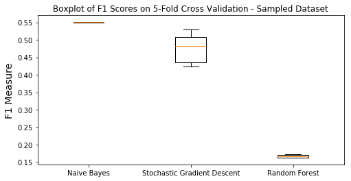

```python
plt.figure(figsize=(8, 4))

plt.boxplot([gnb_scores, sgd_scores, rfs_scores],
            labels=("Naive Bayes",
                    "Stochastic Gradient Descent", "Random Forest"))

plt.ylabel("F1 Measure", fontsize=14)
plt.title("Boxplot of F1 Scores on 5-Fold Cross Validation - Sampled Dataset")
plt.show()
```

## Comments on Baseline Models

Performance is quite bad overall. This could be due to messy data and the source of the data is unknown i.e. possibly synthetic data. Also, the class label is `Potential Fraud` meaning that it is not proven fraud and thus, the labels may not be reliable and have a lot of associated noise.

Naive Bayes

- Performed the best and had a very low standard deviation.

Stochastic Gradient Descent

- Performed better than random forest but not as well as NB

Random Forest

- The worst out of the 3 model and took a while to run also.
- Would likely perform better with more estimators and data

Support Vector Machines were tried as well but had a very long run time. Logistic Regression also had very bad performance (~0) so it was not included.

Since Naive Bayes cannot be fine tuned, we will explore if Stochastic Gradient Descent can be improved further

# Fine-Tuning Promising Models

```python
# Re-run preprocessing with larger sample
trainX, testX, trainY, testY = train_test_split(X, Y, test_size = 0.2,
                                         random_state = 42)

sample_fraction = 0.5

trainX = trainX.sample(frac = sample_fraction, random_state = 42)
trainY = trainY[trainY.index.isin(trainX.index)]

trainX_tr = full_pipeline.fit_transform(trainX)
print(trainX_tr.shape)
print(trainY.shape)
```

```
(223284, 526)
(223284,)
```

## Using Grid Search for Model Parameters

```python
from sklearn.model_selection import GridSearchCV
import time

# Getting some f1 warnings
# https://stackoverflow.com/questions/43162506/undefinedmetricwarning-f-score-is-ill-defined-and-being-set-to-0-0-in-labels-wi

import warnings
warnings.filterwarnings('ignore')

param_grid = {"max_iter": [1, 5, 10],
              "alpha": [0.001, 0.01, 0.1, 1, 10],
              "penalty": ["none", "l1", "l2"]}

# run grid search
grid_search = GridSearchCV(sgd_clf, param_grid = param_grid,
                          scoring="f1", cv=5)
t0 = time.time()
grid_search.fit(trainX_tr, trainY)
print("It took {} seconds to do a grid search".format(round(time.time()-t0, 2)))
```

```
It took 371.13 seconds to do a grid search
```

```python
grid_search.best_params_
```

```
{'alpha': 10, 'max_iter': 1, 'penalty': 'l1'}
```

```python
grid_search.best_estimator_
```

```
SGDClassifier(alpha=10, average=False, class_weight=None,
       early_stopping=False, epsilon=0.1, eta0=0.0, fit_intercept=True,
       l1_ratio=0.15, learning_rate='optimal', loss='hinge', max_iter=1,
       n_iter=None, n_iter_no_change=5, n_jobs=None, penalty='l1',
       power_t=0.5, random_state=42, shuffle=True, tol=None,
       validation_fraction=0.1, verbose=0, warm_start=False)
```

```python
scores = pd.DataFrame(grid_search.cv_results_)
scores.sort_values(by = ['mean_test_score'], ascending = False)[:5]
```

|  | mean_fit_time | mean_score_time | mean_test_score | mean_train_score | param_alpha | param_max_iter | param_penalty | params | rank_test_score | split0_test_score | ... | split2_test_score | split2_train_score | split3_test_score | split3_train_score | split4_test_score | split4_train_score | std_fit_time | std_score_time | std_test_score | std_train_score |
| --- | --- | --- | --- | --- | --- | --- | --- | --- | --- | --- | --- | --- | --- | --- | --- | --- | --- | --- | --- | --- | --- |
| 37 | 0.696176 | 0.042615 | 0.441879 | 0.441881 | 10 | 1 | l1 | {'max_iter': 1, 'penalty': 'l1', 'alpha': 10} | 1 | 0.552353 | ... | 0.552353 | 0.552350 | 0.000000 | 0.000000 | 0.552339 | 0.552353 | 0.096895 | 0.007751 | 0.220940 | 0.220940 |
| 43 | 3.030769 | 0.037626 | 0.441879 | 0.441881 | 10 | 10 | l1 | {'max_iter': 10, 'penalty': 'l1', 'alpha': 10} | 1 | 0.552353 | ... | 0.552353 | 0.552350 | 0.000000 | 0.000000 | 0.552339 | 0.552353 | 0.253655 | 0.006356 | 0.220940 | 0.220940 |
| 40 | 1.632056 | 0.034837 | 0.441879 | 0.441881 | 10 | 5 | l1 | {'max_iter': 5, 'penalty': 'l1', 'alpha': 10} | 1 | 0.552353 | ... | 0.552353 | 0.552350 | 0.000000 | 0.000000 | 0.552339 | 0.552353 | 0.139365 | 0.008645 | 0.220940 | 0.220940 |
| 36 | 0.467405 | 0.045141 | 0.350135 | 0.349852 | 10 | 1 | none | {'max_iter': 1, 'penalty': 'none', 'alpha': 10} | 4 | 0.454796 | ... | 0.405698 | 0.406724 | 0.113045 | 0.111358 | 0.389966 | 0.393851 | 0.027642 | 0.014710 | 0.121005 | 0.121420 |
| 39 | 1.307093 | 0.035664 | 0.311482 | 0.313137 | 10 | 5 | none | {'max_iter': 5, 'penalty': 'none', 'alpha': 10} | 5 | 0.357497 | ... | 0.331974 | 0.333762 | 0.178284 | 0.176909 | 0.375292 | 0.377664 | 0.194327 | 0.008634 | 0.069798 | 0.071341 |

5 rows × 23 columns

## Trying to Improve GridSearch

- `max_iter` had no affect on performance, 1 has fasted run time.
- `penalty` will be set to *l1*
- We will try larger values for `alpha` and change additional parameters
- We will also try setting the class weight to be inversely proportional to class frequencies

```python
sgd_clf = SGDClassifier(random_state = 42, max_iter=1, penalty = 'l1')

param_grid2 = {"alpha": [10, 20],
              "class_weight" : ["balanced", None]}

# run grid search
grid_search2 = GridSearchCV(sgd_clf, param_grid = param_grid2,
                          scoring="f1", cv=5)
t0 = time.time()
grid_search2.fit(trainX_tr, trainY)
print("It took {} seconds to do a grid search".format(round(time.time()-t0, 2)))
```

```
It took 16.41 seconds to do a grid search
```

```python
grid_search2.best_params_
```

```
{'alpha': 10, 'class_weight': 'balanced'}
```

Still the same alpha, but we have a better estimator with the class weight set as balanced. We now have two possible models to choose from. In the next section we will evaluate these further.

```python
final_sgd_model = grid_search2.best_estimator_
final_nb_model = GaussianNB()
```

# Model Evaluation

## Confusion Matrix

```python
# Use cross_val_predict to get only predicted values from the training data
from sklearn.model_selection import cross_val_predict

trainY_pred_sgd = cross_val_predict(final_sgd_model, trainX_tr, trainY, cv=5)
trainY_pred_nb = cross_val_predict(final_nb_model, trainX_tr.todense(), trainY, cv=5)
```

```python
from sklearn.metrics import confusion_matrix
from sklearn.metrics import precision_score, recall_score

def plot_cm(predictions, title = "Confusion Matrix"):
    """Function to plot confusion matrix"""

    cm = confusion_matrix(trainY, predictions)
    # Show as percentages
    cm = cm.astype('float') / cm.sum(axis=1)[:, np.newaxis]

    plt.figure(figsize=(8, 4))
    ax= plt.subplot()
    sns.heatmap(cm, annot=True, ax = ax); #annot=True to annotate cells

    # labels, title and ticks
    ax.set_xlabel('Predicted labels');ax.set_ylabel('True labels');
    ax.set_title(title);
    ax.xaxis.set_ticklabels(['Non Fraud', 'Fraud']); ax.yaxis.set_ticklabels(['Non Fraud', 'Fraud']);

    print("Precision: ", precision_score(trainY, predictions))
    print("Recall: ", recall_score(trainY, predictions))
```

```
Precision:  1.0
Recall:  1.0
```

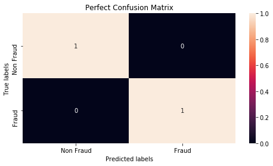

```python
# Perfect Confusion Matrix
plot_cm(trainY, "Perfect Confusion Matrix")
```

```
Precision:  0.38154926186970617
Recall:  0.7999976524168368
```

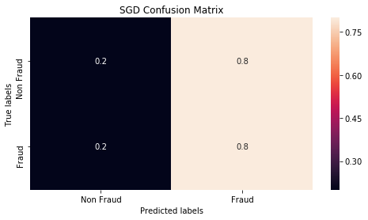

```python
plot_cm(trainY_pred_sgd, "SGD Confusion Matrix")
```

```
Precision:  0.38163016643012626
Recall:  0.9816066859168486
```

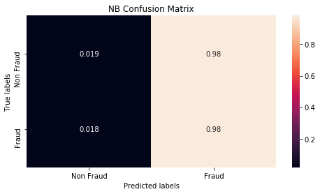

```python
plot_cm(trainY_pred_nb, "NB Confusion Matrix")
```

Both models show a high recall and low precision.

**The amount of truly fraudulent transactions among those that are classified as fraudulent is low, that is a large number of the "positive" predictions are wrong.**

Let's see what happens if we change the threshold. We'll start by looking at precision recall curve.

GaussianNB doesn't have thresholds so we will drop it from here

## Precision Recall Curve

```python
# To get thresholds we need scores of all predictions
trainY_scores_sgd = cross_val_predict(final_sgd_model, trainX_tr, trainY,
                                      cv=5, method = "decision_function")
```

```python
from sklearn.metrics import precision_recall_curve

precisions, recalls, thresholds = precision_recall_curve(trainY, trainY_scores_sgd)
```

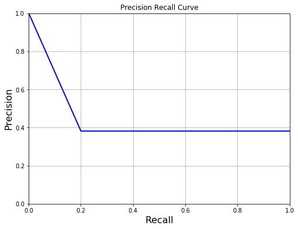

```python
# Plot curve

def plot_precision_vs_recall(precisions, recalls):
    plt.plot(recalls, precisions, "b-", linewidth=2)
    plt.xlabel("Recall", fontsize=16)
    plt.ylabel("Precision", fontsize=16)
    plt.axis([0, 1, 0, 1])
    plt.grid(True)

plt.figure(figsize=(8, 6))
plot_precision_vs_recall(precisions, recalls)
plt.title("Precision Recall Curve")
plt.show()
```

Doesn't look good. Cannot have higher than 0.4 Precision without drastically reducing the Recall.

## ROC Curve

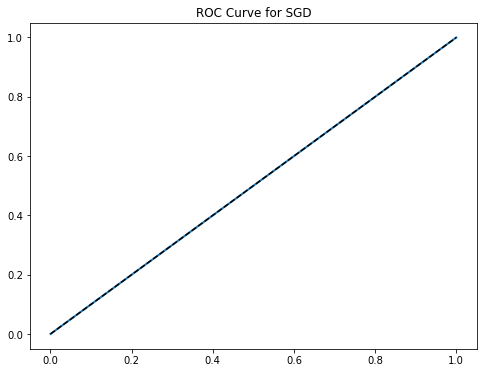

```python
from sklearn.metrics import roc_curve

fpr, tpr, thresholds = roc_curve(trainY, trainY_scores_sgd)


def plot_roc_curve(fpr, tpr, label=None):
    plt.plot(fpr, tpr, linewidth=2, label=label)
    plt.plot([0, 1], [0, 1], 'k--') # dashed diagonal

plt.figure(figsize=(8, 6))
plot_roc_curve(fpr, tpr)
plt.title("ROC Curve for SGD")
plt.show()
```

Seems to be no better than guessing!

Will try with full training set.

```
(446568, 528)
(446568,)
Getting Scores
```

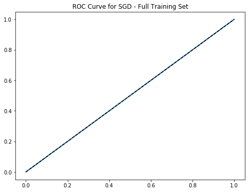

```python
# Re-run preprocessing with full training set
trainX, testX, trainY, testY = train_test_split(X, Y, test_size = 0.2,
                                         random_state = 42)

trainX_tr = full_pipeline.fit_transform(trainX)
print(trainX_tr.shape)
print(trainY.shape)

print("Getting Scores")
trainY_scores_sgd = cross_val_predict(final_sgd_model, trainX_tr, trainY,
                                      cv=5, method = "decision_function")

fpr, tpr, thresholds = roc_curve(trainY, trainY_scores_sgd)
plt.figure(figsize=(8, 6))
plot_roc_curve(fpr, tpr)
plt.title("ROC Curve for SGD - Full Training Set")
plt.show()
```

There is no difference, thus it seems as though the model is not picking up any meaningful patterns and it's predictions are a good as random. For conclusiveness, we will still evaluate this tuned model on the test set.

# Evaluating on the Out-of-Sample Data

Measuring the generalization error.

```python
# Fit pipeline on all categories - not ideal
full_pipeline.fit(trainX)

# Apply preprocessing pipeline to test data.
testX_tr = full_pipeline.transform(testX)

# Fit model with training data
final_sgd_model.fit(trainX_tr, trainY)

# Predict y test data
y_pred = final_sgd_model.predict(testX_tr)
```

```python
def plot_out_of_sample_cm(predictions, title = "Confusion Matrix - Out of Sample Data"):
    """Function to plot confusion matrix"""

    cm = confusion_matrix(testY, predictions)
    # Show as percentages
    cm = cm.astype('float') / cm.sum(axis=1)[:, np.newaxis]

    plt.figure(figsize=(8, 4))
    ax= plt.subplot()
    sns.heatmap(cm, annot=True, ax = ax); #annot=True to annotate cells

    # labels, title and ticks
    ax.set_xlabel('Predicted labels');ax.set_ylabel('True labels');
    ax.set_title(title);
    ax.xaxis.set_ticklabels(['Non Fraud', 'Fraud']); ax.yaxis.set_ticklabels(['Non Fraud', 'Fraud']);

    print("Precision: ", precision_score(testY, predictions))
    print("Recall: ", recall_score(testY, predictions))
```

```
Precision:  0.0
Recall:  0.0
```

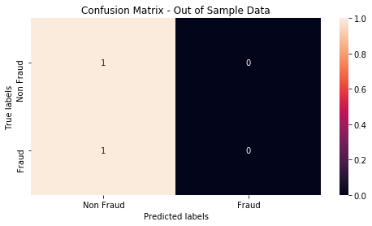

```python
plot_out_of_sample_cm(y_pred)
```

# Concluding Toughts

From the confusion matrix it's apparent that there is some underlying issue with the data or the model that unfortunately was not figured out in the time frame of this assignment.

Apart from a simple mistake that could have been made in the code for this project, there are a number of possible reasons that have caused the model performance.

1. Unreliable labels, since we do not know the origin of the data.
2. Not enough computational power to test out more complex models that would uncover patterns.